# Topic 4 Exercises: Classification

## 4.7

### 1

Let $e^{\beta_0+\beta_1X} = Y$ so that

$$\begin{align}
p(X)&=\frac{e^{\beta_0+\beta_1X}}{1+e^{\beta_0+\beta_1X}} \\
&=\frac{Y}{1+Y}
\end{align}$$

Then
$$\begin{align*}
Y &= p(X)(1+Y)\\
&= p(X)+p(X)\ Y\\
\end{align*}\\
Y-p(X)\ Y =p(X)\\
Y(1-p(X)) = p(X)\\
Y=\frac{p(X)}{1-p(X)}\\
e^{\beta_0+\beta_1X}=\frac{p(X)}{1-p(X)}$$

### 8

We should prefer to use the logistic classification. 1-nearest neighbors will perfectly predict the training data, so the training error will be 0%, and since the average of the training and test error is 18%, the test error must be 36%. This is higher than the 30% error rate on the test data for the logistic regression. Since the test error represents the expected error on new, unseen data, the logistic classification method will be more accurate for new observations.

### 9

#### a)

Let $p$ be the probability and $o$ be the odds.
$$\begin{align}
p&=\frac{o}{1+o}\\
&=\frac{0.37}{1.37}\\
&\approx 0.27
\end{align}$$

#### b)

$$\begin{align}
o&=\frac{p}{1-p}\\
&=\frac{0.16}{0.84}\\
&\approx 0.19
\end{align}$$

### 11

#### a)

```r
require(ISLR)
require(ggplot2)
require(gridExtra)
Auto <- within(Auto, mpg01 <- as.numeric(mpg > median(mpg)))
```

#### b)

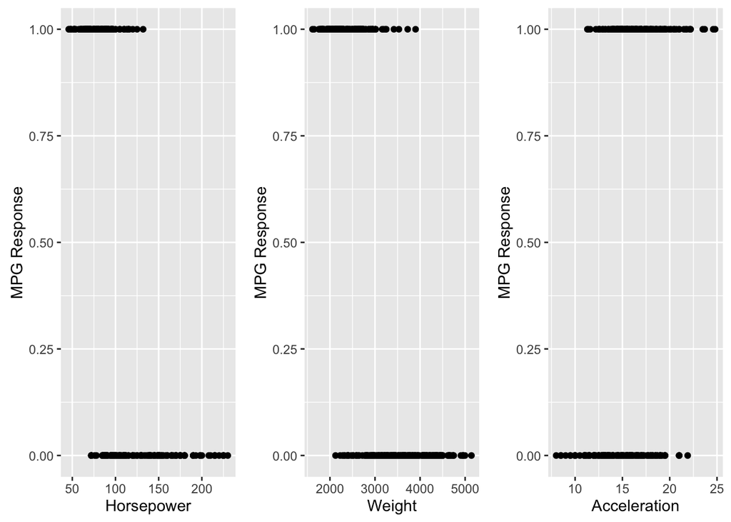

```r
ylab <- 'MPG Response'
plot_horsepower <- ggplot(Auto, aes(horsepower, mpg01)) +
  geom_point() + labs(x='Horsepower', y=ylab)
plot_weight <- ggplot(Auto, aes(weight, mpg01)) +
  geom_point() + labs(x='Weight', y=ylab)
plot_acceleration <- ggplot(Auto, aes(acceleration, mpg01)) +
  geom_point() + labs(x='Acceleration', y=ylab)
grid.arrange(plot_horsepower, plot_weight, plot_acceleration, ncol=3)
```

Horsepower, weight, and acceleration seem to have a relationship to the created MPG response variable. The other variables in the data frame do not appear to be correlated (such as displacement and year) or are not quantitative (such as name).

#### c)

```r
set.seed(1)
n <- nrow(Auto)
train_set <- 1:n %in% sample(1:n, 0.75*n)
training_data <- Auto[train_set,]
test_data <- Auto[!train_set,]
```

#### d)

```r
library(MASS)
calc_mspe <- function(mod, response) {
  if ('glm' %in% class(mod)) {
    pred <- predict(mod, newdata = test_data, type = 'response') > 0.5
  } else if (any(c('lda', 'qda') %in% class(mod))) {
    pred <- predict(mod, newdata = test_data)$class
  }
  mean((pred != response)^2)
}
mod_formula <- mpg01 ~ horsepower + weight + acceleration
mod_lda <- lda(mod_formula, data = training_data)
calc_mspe(mod_lda, test_data[["mpg01"]])
```

```
## [1] 0.1428571
```

#### e)

```r
mod_qda <- qda(mod_formula, data = training_data)
calc_mspe(mod_qda, test_data[["mpg01"]])
```

```
## [1] 0.1326531
```

#### f)

```r
mod_log <- glm(mod_formula,
               data = training_data, family = 'binomial')
calc_mspe(mod_log, test_data[["mpg01"]])
```

```
## [1] 0.122449
```

#### g)

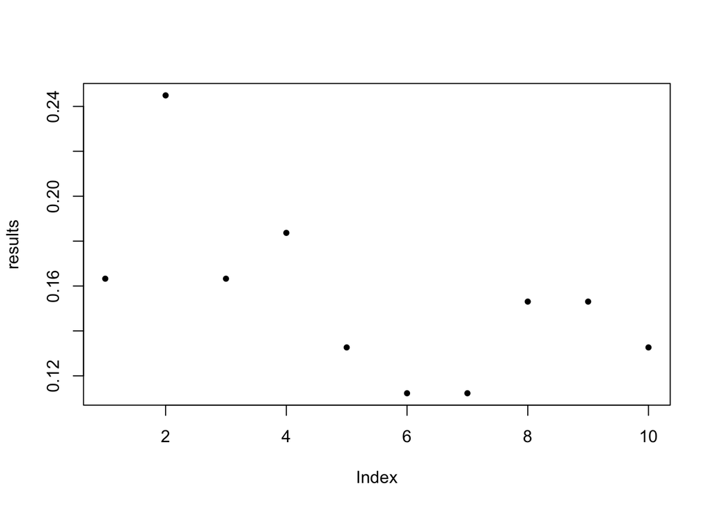

```r
library(class)
training_knn <- training_data[,all.vars(mod_formula)[-1]]
testing_knn <- test_data[,all.vars(mod_formula)[-1]]
labels_knn <- training_data[,all.vars(mod_formula)[1]]
results <- sapply(1:10, function(k) {
  pred_knn <- knn(training_knn, testing_knn, labels_knn, k=k)
  out <- mean((pred_knn != test_data[['mpg01']])^2)
  names(out) <- k
  out
})
plot(results, pch=20)
```

```r
results[which.min(results)]
```

```
##         6
## 0.1122449
```

The best value for k for this data set is 6 or 7.

### 13

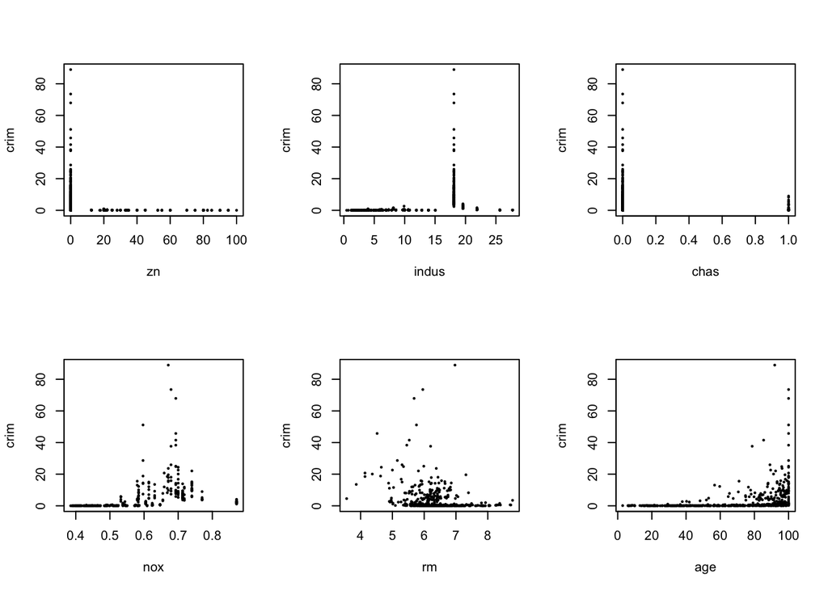

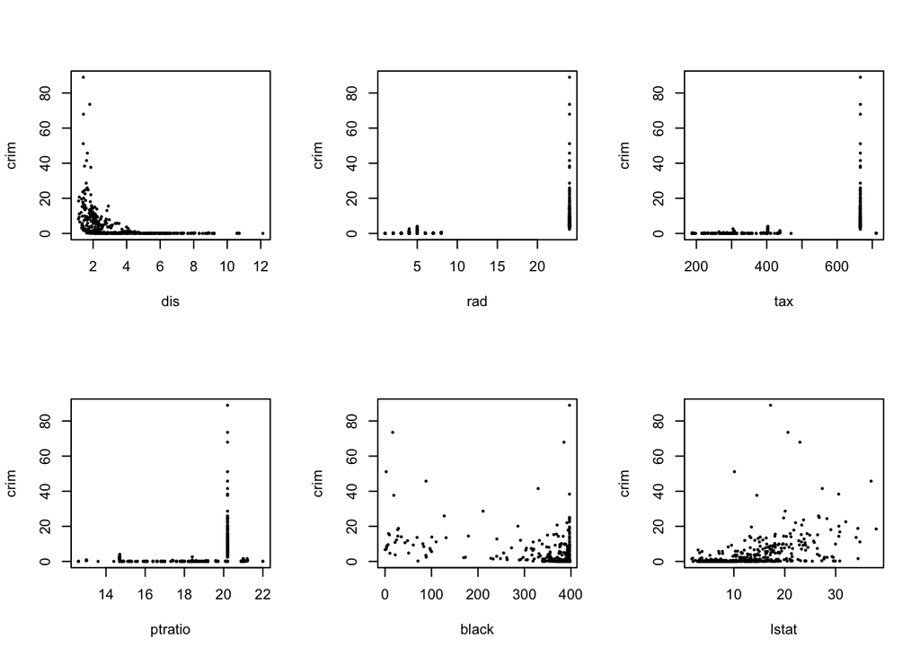

```r
par(mfrow = c(2, 3))
for (name in names(Boston)[-1]) {
  plot(Boston[[name]], Boston[['crim']], pch=20, cex=0.4, xlab=name, ylab='crim')
}
```

```r
sort(abs(cor(Boston)[1,]), decreasing = T)
```

```
##       crim        rad        tax      lstat        nox      indus
## 1.00000000 0.62550515 0.58276431 0.45562148 0.42097171 0.40658341
##       medv      black        dis        age    ptratio         rm
## 0.38830461 0.38506394 0.37967009 0.35273425 0.28994558 0.21924670
##         zn       chas
## 0.20046922 0.05589158
```

[figure not shown]

```r
Boston <- within(Boston, crim_res <- crim > median(crim))
set.seed(1)
n <- nrow(Boston)
train_set <- 1:n %in% sample(1:n, 0.7*n)
training_data <- Boston[train_set,]
test_data <- Boston[!train_set,]
```

```r
model_errors <- function(mod_formula) {
  mod_log <- glm(mod_formula, data = training_data, family = 'binomial')
  a <- calc_mspe(mod_log, test_data[['crim_res']])

  mod_lda <- lda(mod_formula, training_data)
  b <- calc_mspe(mod_lda, test_data[['crim_res']])

  vars <- all.vars(mod_formula)
  training_knn <- training_data[,vars[-1], drop = FALSE]
  testing_knn <- test_data[,vars[-1], drop = FALSE]
  labels_knn <- training_data[,vars[1]]
  results <- sapply(1:10, function(k) {
    pred_knn <- knn(training_knn, testing_knn, labels_knn, k=k)
    out <- mean((pred_knn != test_data[['crim_res']]))
    names(out) <- k
    out
  })
  list(logistic = a, lda = b, knn = results[which.min(results)])
}
model_errors(crim_res ~ nox)
```

```
## $logistic
## [1] 0.1907895
##
## $lda
## [1] 0.1710526
##
## $knn
##          3
## 0.04605263
```

```r
model_errors(crim_res ~ rad + tax + lstat)
```

```
## $logistic
## [1] 0.2236842
##
## $lda
## [1] 0.2565789
##
## $knn
##          1
## 0.07236842
```

```r
model_errors(crim_res ~ rad + tax + lstat + nox)
```

```
## $logistic
## [1] 0.09210526
##
## $lda
## [1] 0.1447368
##
## $knn
##          1
## 0.07236842
```

```r
model_errors(crim_res ~ rad + tax + nox)
```

```
## $logistic
## [1] 0.09210526
##
## $lda
## [1] 0.1381579
##
## $knn
##          1
## 0.04605263
```